# Lecture 15: The Structure of Scientific Revolutions

This is important

Dr. Gordon Wright

g.wright@gold.ac.uk

Mon 10 Feb, 2025

## The Structure of Scientific Revolutions

### Thomas Kuhn (1962)

#### Understanding Scientific Change & Progress

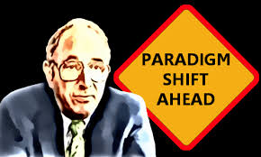

Historical image of Thomas Kuhn

## Legacy

- One of the most influential books about science ever written
- Revolutionized how we think about scientific progress
- Key relevance for psychology and cognitive science today

## Key Concepts We’ll Cover

- Normal Science & Paradigms
- Scientific Revolutions & Crisis
- Incommensurability
- Case Studies from History of Science
- Applications to Psychology
- Modern Relevance (AI Revolution)

## What is Normal Science?

- Scientists working within an accepted framework
- “Puzzle-solving” activities
- Based on shared assumptions and methods
- Example: Current cognitive psychology research paradigm
- Textbooks play crucial role in maintaining normal science

## Paradigms: The Core Concept

A paradigm is:

- Shared worldview within scientific community
- Set of exemplary solutions/methods
- Framework for what counts as legitimate problems
- Not just theory - includes practices, tools, values

## Paradigms

> “Scientists work from models acquired through education & subsequent exposure to the literature often without quite knowing or needing to know what characteristics have given these models the status of community paradigms”

## Components of a Paradigm

1. Symbolic generalizations (e.g., F=ma)
2. Metaphysical commitments
3. Values
4. Exemplars (concrete problem solutions)

## Diagram

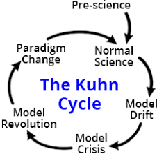

## Case Study: The Copernican Revolution

- Pre-Copernican paradigm: Earth-centered universe
- Anomalies accumulated over time
- Copernicus proposed radical alternative
- Resistance from established community
- Eventually led to complete worldview change

[figure not shown]

Copernican solar system diagram

## Scientific Crisis

- Accumulation of anomalies
- Existing paradigm cannot explain new findings
- Loss of confidence in current methods
- Proliferation of competing theories
- Example in Psychology: Behaviorism crisis

## Scientific Revolutions

- Paradigm shift occurs
- “Scientific revolution” = complete perspective change
- Not just new knowledge - new way of seeing
- Cannot be reduced to rule-following
- Involves conversion experience

## Incommensurability

- Different paradigms cannot be directly compared
- Use different concepts, see different things
- Communication difficulties between paradigms
- No neutral observation language
- Example: Behaviorist vs Cognitive descriptions

## Historical Case Study: Chemistry Revolution

- Phlogiston theory vs Oxygen theory
- Lavoisier’s new paradigm
- Changed basic concepts of element/compound
- Transformed experimental practices
- Parallel to modern psychology shifts?

## Psychology’s Paradigm Shifts: A Deeper Look

## 1. Introspectionism (1879-1920s)

- Wundt’s experimental psychology
- Focus on conscious experience
- Structured self-observation methods
- Titchener’s systematic introspection
- Crisis: Unreliable results, lack of replication

## 2. Behaviorism (1920s-1960s)

- Watson’s rejection of consciousness
- Observable behavior only
- Stimulus-response mechanisms
- Skinner’s radical behaviorism
- Crisis: Cannot explain language, thought, memory

## The Behaviorist Paradigm in Detail

## Key Assumptions

- Mind is a “black box”
- Learning through conditioning
- Environmental determinism
- Rejection of mental states

## Methods

- Animal studies
- Conditioning experiments
- Controlled environment
- Quantitative measurement

## The Cognitive Revolution (1950s-1960s)

## Catalysts

- Chomsky’s critique of Skinner
- Information theory development
- Computer science emergence
- Memory research breakthroughs

## Key Figures

- Jerome Bruner
- George Miller
- Ulric Neisser
- Donald Broadbent

## An exciting amalgam

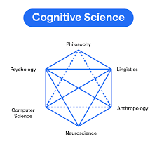

## Cognitive Psychology Paradigm

### Core Metaphor: Mind as Computer

- Information processing
- Memory storage and retrieval
- Mental representations
- Computational procedures

## Methods

- Reaction time studies
- Protocol analysis
- Experimental tasks
- Computer modeling

## Neuroscience Revolution (1990s-2000s)

### Enabling Technologies

- fMRI imaging
- EEG advances
- Optogenetics
- Neural recording

## New Understanding

- Brain networks
- Neural correlates
- Plasticity
- Embodied cognition

## Barely imaginable without this

[figure not shown]

Brain imaging technology

## Current AI Revolution

### Key Developments

- Deep learning success
- GPT language models
- Computer vision advances
- Reinforcement learning

## Challenges to Traditional Views

- Emergence vs representation
- Distributed vs modular processing
- Learning without explicit rules
- Scale of computation

## AI Impact on Psychological Theory

### Traditional Cognitive Models

- Rule-based processing
- Symbolic representations
- Modular systems
- Sequential processing

## AI-Inspired Models

- Parallel distributed processing
- Emergent properties
- Statistical learning
- Dynamic systems

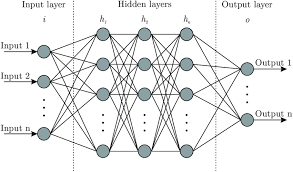

Neural network architecture

## Current Debates in AI-Psychology

### 1. Consciousness

- Integrated Information Theory
- Global Workspace Theory
- Predictive Processing

## 2. Intelligence

- Multiple intelligences
- Artificial vs natural
- General vs specific

## 3. Learning

- Deep learning principles
- Transfer capabilities
- Role of innate structure

## Evidence of Paradigm Crisis?

### Current Anomalies

- Replication failures
- Limited ecological validity
- Theory-practice gap
- Integration problems

## Emerging Questions

- Role of consciousness
- Nature of intelligence
- Boundaries of cognition
- Human-AI interaction

## Future Integration?

### Potential Synthesis

- Computational neuroscience
- Cognitive architectures
- Hybrid AI systems
- Embodied robotics

## Research Directions

- Brain-computer interfaces
- Augmented cognition
- Social-technical systems
- Collective intelligence

## Key Critics & Alternative Views

### Philosophy of Science after Kuhn

- Kuhn’s work sparked major debates
- Three key alternative perspectives:
  - Karl Popper: Falsificationism
  - Imre Lakatos: Research Programs
  - Paul Feyerabend: Epistemological Anarchism

## “Critical!”

[figure not shown]

Philosophy debate illustration

## Karl Popper’s Falsificationism

- Science advances through bold conjectures and refutations
- No amount of evidence can prove a theory true
- But one counterexample can prove it false
- Focus on crucial experiments that could falsify theories
- Criticized Kuhn’s “normal science” as too dogmatic

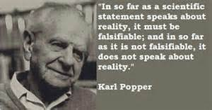

## Popper vs Kuhn

### Popper

- Science should actively seek falsification
- Clear demarcation between science and non-science
- Progress through rational criticism

## Kuhn

- Scientists typically defend paradigms
- No clear demarcation criteria
- Progress through revolution and conversion

## Imre Lakatos: Research Programs

- Attempted synthesis between Kuhn and Popper
- Science organized into “Research Programs” with:
  - “Hard core” of fundamental assumptions
  - “Protective belt” of auxiliary hypotheses
  - Positive and negative heuristics

## Imre Lakatos

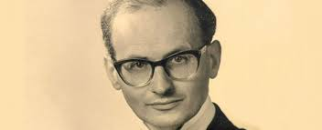

## Progressive vs Degenerating Programs

### Progressive Programs

- Make novel predictions
- Explain new phenomena
- Generate new research

### Degenerating Programs

- Only explain known facts
- Make ad hoc modifications
- Lose predictive power

## Paul Feyerabend: Against Method

- Rejected both Kuhn and Popper
- “Anything goes” in scientific method
- Science shouldn’t be privileged over other forms of knowledge
- Progress requires breaking all rules
- Advocated theoretical anarchism

## Punk Paul

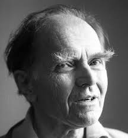

Feyerabend portrait

## Feyerabend’s Critique of Kuhn

- Paradigms can and should coexist
- No single scientific method
- Progress through proliferation of theories
- Science needs external criticism
- Democracy over expert authority

## Relevance for Psychology

### Key Questions

1. Is psychology falsifiable? (Popper)
2. What are our research programs? (Lakatos)
3. Should we embrace methodological pluralism? (Feyerabend)
4. How do these views inform current debates?

## Discussion Questions

1. Are we currently in a paradigm crisis in psychology?
2. How does AI challenge our understanding of mind?
3. What would constitute evidence of a paradigm shift?
4. Can multiple paradigms coexist productively?
5. How should psychology education adapt?

## Key Takeaways

1. Science progresses through paradigm shifts
2. Psychology has experienced multiple revolutions
3. AI may represent current paradigm crisis
4. Awareness of paradigms crucial for researchers
5. Balance needed between stability and change

## Thank You

### Questions & Discussion

> “The successive transition from one paradigm to another via revolution is the usual developmental pattern of mature science.” - Thomas Kuhn

[figure not shown]

Research Methods Lecture 15 - Kuhn